# Predict Future Elk Harvest

Pierre Sarnow

## Description

Use historical harvests, number of hunters, and weather data to predict the harvest for the upcoming hunting seasons.

**NOTICE** that I am only looking at the general rifle hunting seasons on public land. There are also hunters for Archery, Muzzleloader, Private Land, Ranching for Wildlife, etc.

## Setup

Load required libraries for wrangling data, charting, and mapping

```r
library(plyr,quietly = T) # data wrangling
library(dplyr,quietly = T) # data wrangling
library(ggplot2, quietly = T) # charting
library(ggthemes,quietly = T) # so I can add the highcharts theme and palette
library(scales,quietly = T) # to load the percent function when labeling plots
library(caret,quietly = T) # classification and regression training
library(foreach,quietly = T) # parallel processing to speed up the model training
library(doMC,quietly = T) # parallel processing to speed up the model training
library(lubridate,quietly = T) # for timing models
```

Set our preferred charting theme

```r
theme_set(theme_minimal()+theme_hc()+theme(legend.key.width = unit(1.5, "cm")))
```

Run script to get hunter data

```r
source('~/_code/colorado-dow/datasets/Colorado Elk Harvest Data.R', echo=F)
```

```
The working directory was changed to /Users/psarnow/_code/colorado-dow/datasets inside a notebook chunk. The working directory will be reset when the chunk is finished running. Use the knitr root.dir option in the setup chunk to change the working directory for notebook chunks.
```

Table of the harvest data

```r
head(COElkRifleAll)
```

```
  Unit Harvest.Antlered Hunters.Antlered Success.Antlered Season HuntCode Harvest.Antlerless Hunters.Antlerless
1    1                0                0               NA      1 EM001O1R                 NA                 NA
2    2                0                0               NA      1 EM002O1R                 NA                 NA
3  201                0                0               NA      1 EM201O1R                 NA                 NA
4    3                0                0               NA      1 EM003O1R                 NA                 NA
5  301                0                0               NA      1 EM301O1R                 NA                 NA
6    4                0                0               NA      1 EM004O1R                 NA                 NA
  Success.Antlerless Hunters.Either Success.Either Year
1                 NA             NA             NA 2006
2                 NA             NA             NA 2006
3                 NA             NA             NA 2006
4                 NA             NA             NA 2006
5                 NA             NA             NA 2006
6                 NA             NA             NA 2006
```

Load the weather data

```r
load("weatherdata5.RData")
head(weatherdata5)
```

| daily.moonPhase | daily.temperatureHigh | daily.temperatureLow | daily.dewPoint | daily.humidity | daily.pressure | daily.windSpeed | daily.cloudCover | daily.precipIntensity | daily.precipProbability | daily.precipType | Season | daily.precipAccumulation | Year | Unit | daily.FullmoonPhase | daily.temperatureMean |
| --- | --- | --- | --- | --- | --- | --- | --- | --- | --- | --- | --- | --- | --- | --- | --- | --- |
| 0.3680000 | 61.34200 | 35.05800 | 29.17800 | 0.5500000 | 1018.334 | 2.324000 | 0.2340000 | 0.0014000000 | 0.15400000 | 1 | 1 | 0.000 | 2010 | 77 | 0.7360000 | 48.20000 |
| 0.6544444 | 50.25778 | 27.79889 | 24.67667 | 0.6155556 | 1018.581 | 6.402222 | 0.3088889 | 0.0014777778 | 0.14222222 | 1 | 2 | 0.000 | 2010 | 77 | 0.6911111 | 39.02833 |
| 0.1555556 | 44.32444 | 21.11111 | 19.44111 | 0.6211111 | 1019.526 | 3.521111 | 0.2655556 | 0.0004111111 | 0.07333333 | 3 | 3 | 0.097 | 2010 | 77 | 0.3111111 | 32.71778 |
| 0.4300000 | 45.20800 | 23.44200 | 11.97600 | 0.4560000 | 1018.438 | 7.992000 | 0.2440000 | 0.0009400000 | 0.17400000 | 2 | 4 | 0.717 | 2010 | 77 | 0.8600000 | 34.32500 |
| 0.6740000 | 65.24400 | 32.92000 | 22.39600 | 0.4140000 | 1019.216 | 2.148000 | 0.0260000 | 0.0000400000 | 0.01600000 | 1 | 1 | 0.000 | 2011 | 77 | 0.6520000 | 49.08200 |
| 0.5522222 | 55.27667 | 31.36444 | 25.96444 | 0.5922222 | 1020.653 | 1.231111 | 0.2744444 | 0.0024888889 | 0.19666667 | 1 | 2 | 0.000 | 2011 | 77 | 0.8955556 | 43.32056 |

source geodata

```r
source('~/_code/colorado-dow/datasets/Colorado GMUnit and Road data.R', echo=F)
```

[output not shown]

Take a peak at the boundary data

```r
head(Unitboundaries2)
```

```
  id      long      lat order  hole piece group COUNTY DEERDAU ELKDAU ANTDAU MOOSEDAU BEARDAU LIONDAU SQ_MILES    ACRES
1  1 -109.0486 40.83476     1 FALSE     1   1.1 MOFFAT     D-1   E-47   A-11     M-99    B-15     L-1 127.2227 81422.53
2  1 -109.0472 40.83357     2 FALSE     1   1.1 MOFFAT     D-1   E-47   A-11     M-99    B-15     L-1 127.2227 81422.53
3  1 -109.0460 40.83295     3 FALSE     1   1.1 MOFFAT     D-1   E-47   A-11     M-99    B-15     L-1 127.2227 81422.53
4  1 -109.0449 40.83228     4 FALSE     1   1.1 MOFFAT     D-1   E-47   A-11     M-99    B-15     L-1 127.2227 81422.53
5  1 -109.0438 40.83204     5 FALSE     1   1.1 MOFFAT     D-1   E-47   A-11     M-99    B-15     L-1 127.2227 81422.53
6  1 -109.0423 40.83181     6 FALSE     1   1.1 MOFFAT     D-1   E-47   A-11     M-99    B-15     L-1 127.2227 81422.53
  SHAPE_area SHAPE_len Unit
1  329506619  100751.7    1
2  329506619  100751.7    1
3  329506619  100751.7    1
4  329506619  100751.7    1
5  329506619  100751.7    1
6  329506619  100751.7    1
```

Set to predictive analytics directory

```r
setwd("~/_code/colorado-dow/phase III - predictive analytics")
```

### Organize data

I could also use the harvest and population estimates to create another elk population number, might be useful in predicting. Because there are some elk not accounted for in DecemberPopulation = JanuaryPopulation - FallHarvest

Group weather data by year

```r
UnitWeather <- summarise(group_by(weatherdata5,Year,Unit),
                         daily.temperatureHigh = max(daily.temperatureHigh,na.rm = T),
                         daily.temperatureLow = min(daily.temperatureLow,na.rm = T),
                         daily.temperatureMean = mean(daily.temperatureMean,na.rm = T),
                         daily.precipAccumulation = mean(daily.precipAccumulation,na.rm = T),
                         daily.precipType = mean(daily.precipType,na.rm = T),
                         daily.windSpeed = mean(daily.windSpeed,na.rm = T),
                         daily.FullmoonPhase = mean(daily.FullmoonPhase,na.rm = T))
```

Appropriate field classes for model training

```r
UnitWeather$Year <- as.numeric(UnitWeather$Year)
```

Group Hunter data by Year and Unit

```r
COElkHarvest <- summarise(group_by(COElkRifleAll,Year,Unit),
                          Harvest = sum(c(Harvest.Antlered,Harvest.Antlerless),na.rm = T),
                          Hunters = sum(c(Hunters.Antlered,Hunters.Antlerless,Hunters.Either),na.rm = T))
COElkHarvest$Year <- as.numeric(COElkHarvest$Year)
```

Join Harvest, Hunter, and Weather data

```r
COElkHarvest <- full_join(COElkHarvest, UnitWeather, by = c("Year","Unit"))
```

Remove rows with missing data

```r
COElkHarvest <- filter(COElkHarvest, !is.na(Harvest) & !is.na(daily.temperatureMean) & Year != 2018)
```

Split into train and test sets. Will use 75% of the data to train on.

```r
COElkHarvest <- mutate(group_by(COElkHarvest,Unit),
                       numentries = n())
COElkHarvest <- filter(COElkHarvest, numentries >= 3)
COElkHarvest$UnitYear <- paste(COElkHarvest$Unit, COElkHarvest$Year)
traindata <- COElkHarvest %>% group_by(Unit) %>% sample_frac(size = .75, replace = F)
testdata <- COElkHarvest[!COElkHarvest$UnitYear %in% traindata$UnitYear,]
COElkHarvest <- select(COElkHarvest, -UnitYear, -numentries)
traindata <- select(traindata, -UnitYear, -numentries)
testdata <- select(testdata, -UnitYear, -numentries)
```

Save off for importing into AzureML

```r
write.csv(COElkHarvest,file = "~/_code/colorado-dow/datasets/COElkHarvest.csv",row.names = F)
```

## Model Building

### Model Training Methods

Loop through possible methods, utilizing the quicker ‘adaptive_cv’ parameter search from caret. Consider scripting this into AzureML to make it run much faster, though there is more setup and errors to control for

```r
quickmethods <- c("lm",'svmLinear',"svmRadial","knn","cubist","kknn")
step1_all <- NULL
for (imethod in quickmethods) {
  step1 <- NULL
  start <- now()

  if (imethod == "lm" | imethod == "svmLinear") {
    controlmethod <- "repeatedcv"
  } else {controlmethod <- "adaptive_cv"}

  fitControl <- trainControl(
    method = controlmethod,
    # search = 'random',
    number = 4,
    repeats = 4,
    allowParallel = TRUE,
    summaryFunction = defaultSummary)

  registerDoSEQ()
  registerDoMC(cores = 6)

  HarvestModel_1 = train(Harvest ~ ., data = traindata,
                         method = imethod,
                         #preProc = c("center","scale"),
                         tuneLength = 15,
                         trControl = fitControl)

  HarvestModel_1

  # measure performance
  predictdata <- predict(HarvestModel_1, testdata)

  step1$method <- imethod
  step1$RMSE <- postResample(pred = predictdata, obs = testdata$Harvest)[1]
  step1$duration <- now() - start
  step1 <- as.data.frame(step1)
  step1_all <- rbind(step1_all,step1)
}
```

[output not shown]

View Results

```r
step1_all
```

```
         method      RMSE       duration
RMSE         lm  52.23203  1.742155 secs
RMSE1 svmLinear  56.67347  1.994666 secs
RMSE2 svmRadial  55.10650  7.456390 secs
RMSE3       knn 105.23611  4.174521 secs
RMSE4    cubist  60.09588  9.766908 secs
RMSE5      kknn  59.56523 15.774304 secs
```

Run the best model with all of the data

```r
fitControl <- trainControl(
    method = "repeatedcv",
    # search = 'random',
    number = 4,
    repeats = 4,
    allowParallel = TRUE,
    summaryFunction = defaultSummary)

registerDoSEQ()
registerDoMC(cores = 6)

HarvestModel_1 = train(Harvest ~ ., data = COElkHarvest,
                         method = 'lm',
                         #preProc = c("center","scale"),
                         tuneLength = 15,
                         trControl = fitControl)

HarvestModel_1
```

```
Linear Regression

704 samples
 10 predictor

No pre-processing
Resampling: Cross-Validated (4 fold, repeated 4 times)
Summary of sample sizes: 527, 527, 529, 529, 528, 529, ...
Resampling results:

  RMSE      Rsquared   MAE
  57.90792  0.9189491  41.26232

Tuning parameter 'intercept' was held constant at a value of TRUE
```

## Predict Hunter for next year, 2018

```r
# Get 2018 Hunters from the Hunters Predicted model
load("~/_code/colorado-dow/datasets/COElkHunters2018_Season.RData")
COElkHunters2018Predicted <- summarise(group_by(COElkHunters2018_Season, Year, Unit),
                                       Hunters = sum(Hunters,na.rm = T))
# ensure we include all of the units
COElkHarvest2018 <- as.data.frame(unique(COElkHarvest$Unit))
colnames(COElkHarvest2018) <- "Unit"
COElkHarvest2018$Year <- 2018
# Weather data for 2018
UnitWeather2018 <- filter(UnitWeather,Year==2018)
# A left join will autofill missing draw data with NAs, but will retain the full list of Units
COElkHarvest2018 <- left_join(COElkHarvest2018,UnitWeather2018)
```

```
Column `Unit` joining factor and character vector, coercing into character vector
```

```r
# Join in forecasted Hunters
COElkHarvest2018 <- left_join(COElkHarvest2018,COElkHunters2018Predicted)
# Replace the hunter data with missing entries
COElkHarvest2018$Hunters[is.na(COElkHarvest2018$Hunters)] <- 0
COElkHarvest2018 <- COElkHarvest2018[, colnames(COElkHarvest2018) %in% c("Unit",HarvestModel_1$coefnames)]
COElkHarvest2018$Harvest <- predict(HarvestModel_1, COElkHarvest2018)
COElkHarvest2018$Harvest[COElkHarvest2018$Harvest<0] <- 0
# Combine with historic data
COElkHarvestAll <- rbind.fill(COElkHarvest,COElkHarvest2018)
```

## View results

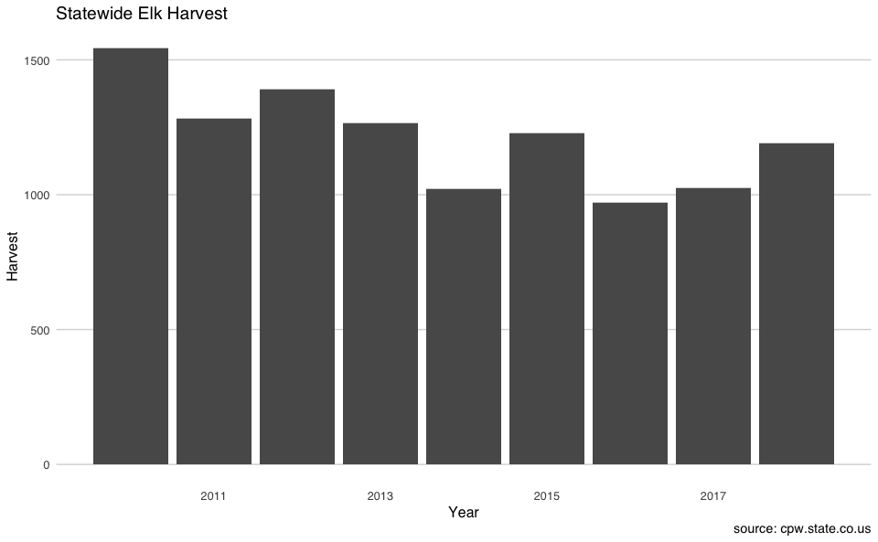

```r
ggplot(COElkHarvestAll, aes(Year,Harvest)) +
  geom_bar(position="dodge",stat="identity") +
  # coord_cartesian(ylim = c(130000,155000)) +
  scale_fill_hc() +
  labs(title="Statewide Elk Harvest", caption="source: cpw.state.co.us")
```

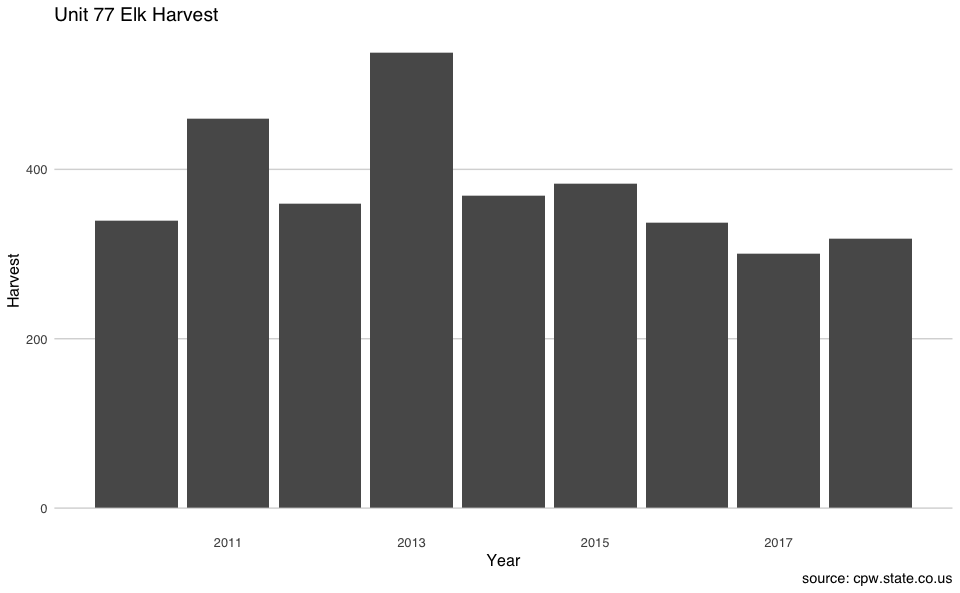

```r
Harvest_77 <- filter(COElkHarvestAll, Unit == "77")
ggplot(Harvest_77, aes(Year,Harvest)) +
  geom_bar(position="dodge",stat="identity") +
  # coord_cartesian(ylim = c(130000,155000)) +
  scale_fill_hc() +
  labs(title="Unit 77 Elk Harvest", caption="source: cpw.state.co.us")
```